# Análise dos Dados Parlamentares 2016

Arthur Lustosa

08/07/2016

```r
#install.packages("dplyr")
#install.packages("ggplot2")
#installed.packages("scales")
library(dplyr, warn.conflicts = FALSE)
library(ggplot2)
library(scales)
theme_set(theme_bw())
```

Para ajudar com nosso entendimento sobre os dados, temos uma [explicação](http://www2.camara.leg.br/transparencia/cota-para-exercicio-da-atividade-parlamentar/explicacoes-sobre-o-formato-dos-arquivos-xml) do que significa cada variável.

```r
summary(data$numAno)
```

```
##    Min. 1st Qu.  Median    Mean 3rd Qu.    Max.
##    2016    2016    2016    2016    2016    2016
```

```r
summary(data$numMes)
```

```
##    Min. 1st Qu.  Median    Mean 3rd Qu.    Max.
##   1.000   2.000   3.000   3.297   4.000   7.000
```

Os dados utilizados nessa análise são de 2016 até o mês de julho.

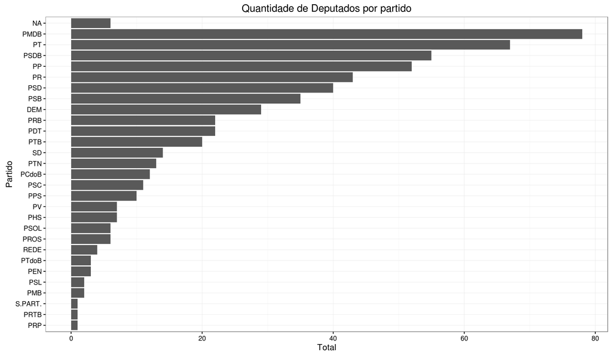

No gráfico de barras 1 vemos a quantidade de deputados por partido. O partido que tem mais representatividade da Câmara Federal é o PMDB com 78 deputados, seguido pelo PT 67 os partidos que tem menos representatividade são PRP e PRTB.

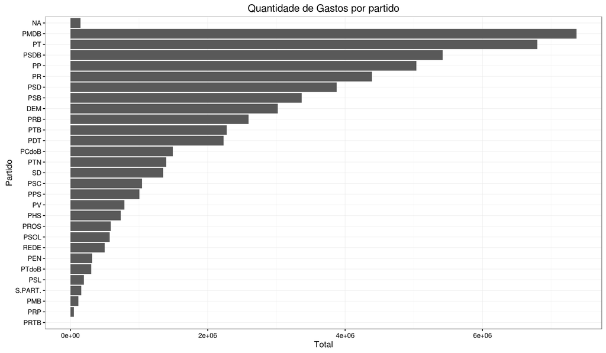

```r
#quantidade de gastos por partido
gastos.por.partido <- data %>%
  filter(vlrDocumento>0 & vlrLiquido>0) %>%
  select(sgPartido, txNomeParlamentar, vlrDocumento) %>%
  distinct() %>%
  group_by(sgPartido) %>%
  summarise(total = sum(vlrDocumento))

#plotanto quantidade de gastos por partido
hist.gastos.por.partido <- ggplot(data=gastos.por.partido, aes(x=reorder(sgPartido, total), y=total)) +
  geom_bar(stat="identity") +
  coord_flip() +
  labs(title="Quantidade de Gastos por partido", x="Partido", y="Total")

hist.gastos.por.partido
```

No gráfico de barras 2 vemos a distribuição de gastos por partido, ou seja, o total de gasto somados de todos os deputados daquele partido. Esse valores são a soma dos valores totais dos documentos emitidos nas prestações de contas.

Quando comparamos o histograma 1 com o 2, concluímos o que já é esperado. Quanto mais deputados, mais gastos determinado partido tem. Os gráficos não são absolutamente idênticos, algumas mudanças ocorrem como por exemplo o PCdoB é o 14º partido com mais deputados, porém na escala de gastos ele sobe para 12º.

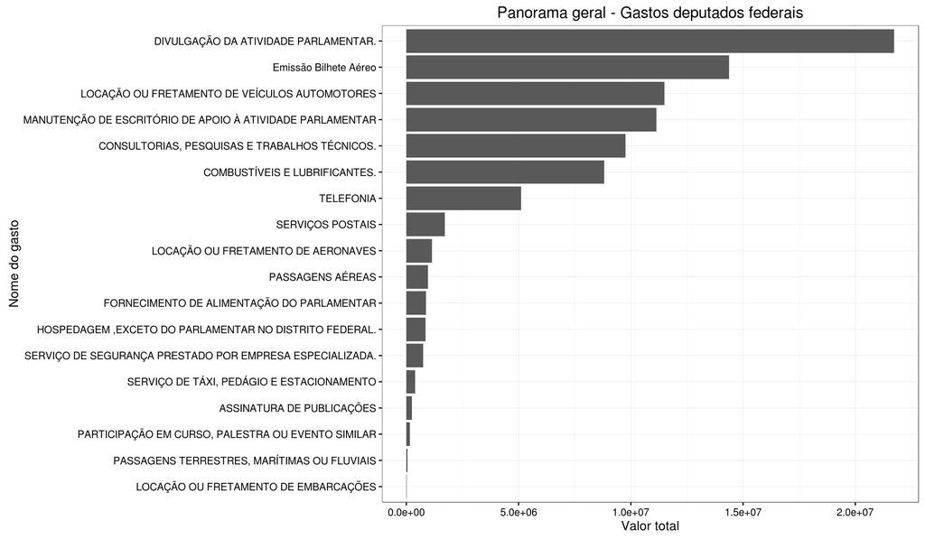

```r
#vendo os tipos de gastos
tiposGastos <- unique(data$txtDescricao)

#agrupando por gastos e vendo os valores dos gastos
gasto.por.tipo <- data %>%
  group_by(txtDescricao) %>%
  summarise(valor.total = sum(vlrDocumento))


#plotando histograma ordenado por valores totais dos gastos
histograma1 <- ggplot(data=gasto.por.tipo, aes(x=reorder(txtDescricao, valor.total), y=valor.total)) +
  geom_bar(stat = "identity") +
  coord_flip() +
  labs(title = "Panorama geral - Gastos deputados federais", x = "Nome do gasto", y = "Valor total")

histograma1
```

O histograma acima nos mostra um panorama geral dos gastos dos deputados de acordo com o seu valor total. Observamos que o maior gasto que nossos deputados realizam é com Divulgação de atividades parlamentares e o menor gasto foi com Locação ou fretamento de embarcações.

### Média de gastos por partido

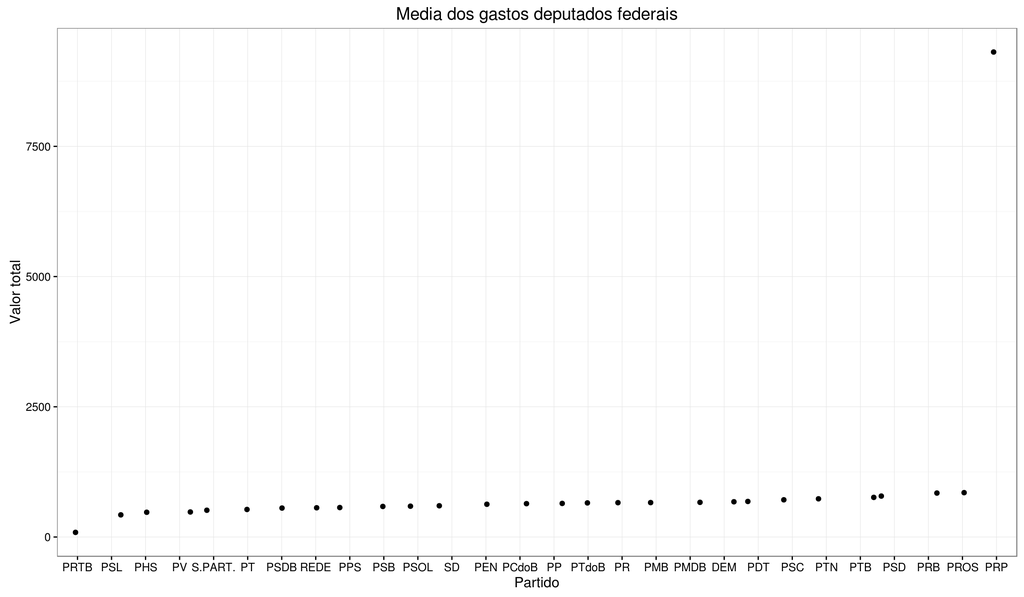

```r
media.gastos.por.partido <- data %>%
  filter(sgPartido != "NA" & vlrDocumento>0 & vlrLiquido>0) %>%
  group_by(sgPartido) %>%
  summarise(media.gastos = mean(vlrDocumento))

grafico.media.gastos.por.partido <- ggplot(data=media.gastos.por.partido, aes(x=reorder(sgPartido, media.gastos), y=media.gastos)) +
  geom_jitter(stat="identity") +
  labs(title = "Media dos gastos deputados federais", x = "Partido", y = "Valor total")

grafico.media.gastos.por.partido
```

No gráfico acima podemos ver a média de gastos por partido. Obsevamos que os partidos se matém numa faixa de valores aparentemente próxima. Temos um ponto atípico nesse gráfico, o partido PRP apresenta-se com sua média de gastos bastante diferente dos demais partidos, isso acontece devido ao número de parlamentares desse partido ser baixo mais precisamente apenas um deputado, com isso, a média de gastos fica concentrada em apenas um ponto, elevando assim seu valor.

Seguindo nossa análise, vamos ver quais o deputados que gastaram mais em 2016.

```r
deputados.que.mais.gastam <- data %>%
  group_by(txNomeParlamentar) %>%
  summarise(valor.total = sum(vlrDocumento)) %>%
  arrange(desc(valor.total))

deputados.que.mais.gastam %>%
  head()
```

```
## Source: local data frame [6 x 2]
##
##      txNomeParlamentar valor.total
##                 <fctr>       <dbl>
## 1 FRANCISCO CHAPADINHA    440522.9
## 2        BETINHO GOMES    268539.2
## 3        DOMINGOS NETO    267290.0
## 4      GIOVANI CHERINI    266232.2
## 5      HIRAN GONÇALVES    264641.5
## 6     ODORICO MONTEIRO    261916.0
```

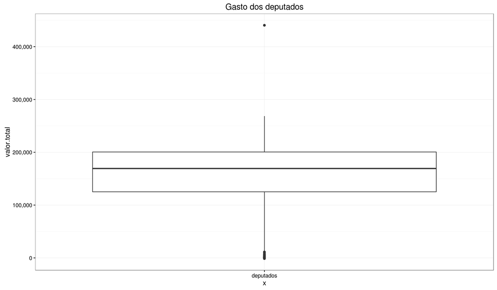

```r
ggplot(deputados.que.mais.gastam, aes(x = "deputados", y = valor.total)) +
  geom_boxplot() +
  scale_y_continuous(labels = comma) +
  ggtitle("Gasto dos deputados")
```

No boxplot acima mostra a relação dos deputados que mais gastam. Temos um outlier (esse ponto extremo acima) é o gasto do deputado Francisco Chapadinha, que se encontra bem acima da mediana de gastos dos outros deputados.

Como mostrado no boxplot acima, o deputado que mais tem gastado em 2016 é o Francisco Chapadinha do PTN-PA. No gráfico abaixo temos uma melhor visão de como o excelentíssimo deputado realiza seus gastos.

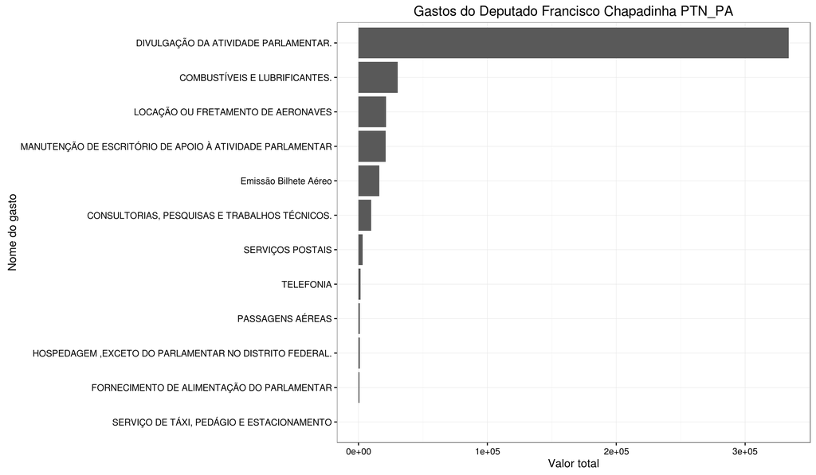

```r
gastos.francisco.chapadinha <- data %>%
  filter(txNomeParlamentar == "FRANCISCO CHAPADINHA") %>%
  group_by(txtDescricao) %>%
  summarise(valor.total = sum(vlrDocumento))

ggplot(gastos.francisco.chapadinha, aes(x=reorder(txtDescricao, valor.total), y=valor.total))+
  geom_bar(stat="identity") +
  coord_flip() +
  labs(title = "Gastos do Deputado Francisco Chapadinha PTN_PA", x = "Nome do gasto", y = "Valor total")
```